# Daniele Rosa's Seminar for GreyAtom

4/27/2019

# Content

- Linear Regression
- Linear Regression using SKLearn
- Regularization and its implementation

# Setting up the compute environment

```python
import os
import sys
import pandas as pd
import numpy as np
import glob
import codecs
from scipy import stats

pd.set_option("max_r",20)
pd.set_option("max_columns",100)
%load_ext autoreload
%autoreload 2

import matplotlib.pyplot as plt
import matplotlib.tri as tri
import matplotlib.dates as mdates
from mpl_toolkits.mplot3d import Axes3D
from matplotlib import cm
from matplotlib.ticker import LinearLocator, FormatStrFormatter
import random

from sklearn.datasets import load_diabetes
from sklearn.linear_model import LinearRegression, Ridge, RidgeCV, Lasso, LassoCV
from sklearn.feature_extraction import DictVectorizer
from sklearn.model_selection import train_test_split
from sklearn.metrics import mean_squared_error, r2_score
from sklearn.model_selection import KFold
from sklearn.model_selection import GridSearchCV
```

# Linear Regression

Between 2 list of values X and y there might be **some sort of hidden relationship** we would like to find.

```python
alpha = 3.2
beta = 5.5

X = [x for x in range(0,10)]
y = [np.round(x*alpha+random.gauss(beta,3),1) for x in X]
```

```python
X
```

```
[0, 1, 2, 3, 4, 5, 6, 7, 8, 9]
```

```python
y
```

```
[4.6, 4.1, 14.2, 16.7, 19.6, 23.2, 24.2, 28.5, 30.0, 33.9]
```

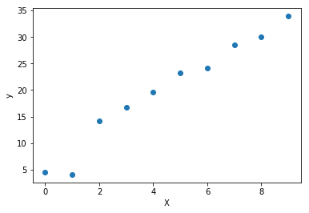

```python
plt.scatter(X,y)
plt.xlabel('X')
ax = plt.ylabel('y')
```

X is usually called the **Explanatory Variables** from *to explain*. The name of X expresses the hope that from knowing its value we may be able to explain, that is to determine, the value of y

y is usually called the **Response Variable** from *to respond*. The name of y expresses the hope that it responds or is determined by X.

### Why the name *Regression* then?

Sir Francis Galton: “Regression towards Mediocrity in Hereditary Stature.”

### Why *Linear*?

Linear because the hidden relationship we are after is going to be a **line**

### Is there a **Best Line**?

$y_{line} = \alpha x + \beta$

If you imaging drawing many lines passing near the points we plotted before. Is there a best line? What are the properties of such line?

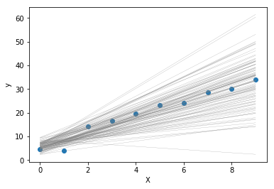

```python
plt.scatter(X,y)
plt.xlabel('X')
ax = plt.ylabel('y')

for i in range(100):
    ialpha = alpha+random.gauss(0,1)
    ibeta = beta+random.gauss(0,2)
    iy = [x*ialpha+ibeta for x in X]
    plt.plot(X,iy,color='grey',lw=0.2)
```

#### The **Best Line** we can find is the line that is as close as possible to **All Points**.

Now we need a measure of *being close*, in other words, we need a measure of distance. The community of people using the *Linear Regression* is in agreement about the distance we should consider and it's called **Sum of Squares Residual (SSR)**

### Sum of Squares Residual (SSR) and R squared (R2)

In red we calculate here the point distance parallel to the y axis between each value of y, **the response variable**, and a line chosen a random.

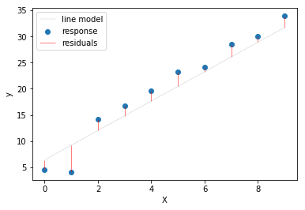

```python
plt.scatter(X,y,label='response')
plt.xlabel('X')
ax = plt.ylabel('y')
ialpha = alpha+random.gauss(0,1)
ibeta = beta+random.gauss(0,2)
iy = [x*ialpha+ibeta for x in X]
plt.plot(X,iy,color='grey',lw=0.2, label='line model')

for i in range(len(X)):
    ymin = min([y[i],iy[i]])
    ymax = max([y[i],iy[i]])
    label = 'residuals' if i == 0 else None
    plt.vlines(x=X[i],ymin=ymin,ymax=ymax,color='r',lw=0.5,label=label)

ax = plt.legend()
```

The SSR is the sum of the squares of the red segments:

$$ SSR = \sum (y_{line,i} - y_i)^2 $$

Where the notation is that $y_i$ are the values of the response variable y, whereas $l_i$ are the values of a line *model*.

A particular case is when the line model is a line with zero slope and intercept equal to the mean response.

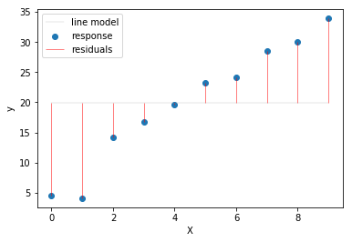

```python
plt.scatter(X,y,label='response')
plt.xlabel('X')
ax = plt.ylabel('y')
ialpha = alpha+random.gauss(0,1)
ibeta = beta+random.gauss(0,2)
iy = [np.mean(y) for x in X]
plt.plot(X,iy,color='grey',lw=0.2, label='line model')

for i in range(len(X)):
    ymin = min([y[i],iy[i]])
    ymax = max([y[i],iy[i]])
    label = 'residuals' if i == 0 else None
    plt.vlines(x=X[i],ymin=ymin,ymax=ymax,color='r',lw=0.5,label=label)

ax = plt.legend()
```

The sum of squares of this special case is called variance and referred to here as:

$$ SSY = \sum (\bar{y} - y_i)^2 $$

If we do a good job in finding the the Best Line, we should expect that:

$$ SSR \le SSY $$

A measure of how good is the Best Line is $R^2$ (or R2):

$$ R2 = 1 - \frac{SSR}{SSY} $$

**The smaller SSR, the larger R2, the better the Best Line is at explaining the response variable**

### Finding the Best Fit Line

It is time to introduce "Fit". It comes from:

*to fit: to be suitable for someone or something*

In fact, *Linear Regression* is also known as *Finding the Best Fit Line*.

Before we said that the best fit line is the line as close as possible to the response variable and we defined a measure of being close, the sum of squares of the residuals. There is a mathematical and a programmatical way to find the best line by minimizing SSR when $\alpha$ and $\beta$ are allowed to vary.

Mathematically, it can be demostrated that:

$$ \beta = \bar{y} - \alpha \bar{x} $$$$ \alpha = \frac{\sum (y_i - \bar{y})(x_i - \bar{x})}{\sum (x_i - \bar{x})^2} $$

Programmatically, one could find the best fit values of $\alpha$ and $\beta$ by exploring their space and looking for when the minimum of $SSR$ occurs.

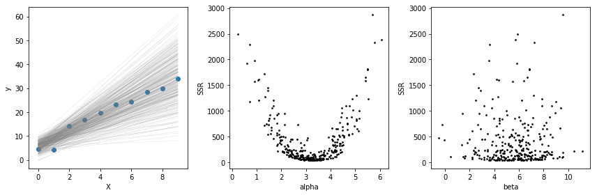

```python
fig = plt.figure(figsize=(12,4))
ax = fig.add_subplot(131)
ax2 = fig.add_subplot(132)
ax3 = fig.add_subplot(133)

ax.set_xlabel('X')
ax.set_ylabel('y')
ax2.set_xlabel('alpha')
ax2.set_ylabel('SSR')
ax3.set_xlabel('beta')
ax3.set_ylabel('SSR')

alphas = []
betas = []
ssrs = []

for i in range(300):
    ibeta = beta+random.gauss(0,2)
    ialpha = alpha+random.gauss(0,1)
    alphas.append(ialpha)
    betas.append(ibeta)
    iy = [x*ialpha+ibeta for x in X]
    ax.plot(X,iy,color='grey',alpha=0.5,lw=0.2)
    ssr = np.sum([(s[0]-s[1])**2 for s in zip(iy,y)])
    ssrs.append(ssr)
    ax2.scatter(ialpha,ssr,color='k',s=3)
    ax3.scatter(ibeta,ssr,color='k',s=3)

ax.scatter(X,y)

plt.tight_layout()
```

#### Using the mathematical formula

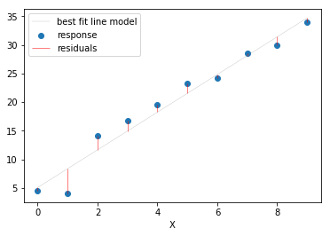

```python
math_alpha = np.dot(np.array(y)-np.mean(y),np.array(X)-np.mean(X)
                   )/np.dot(np.array(X)-np.mean(X),np.array(X)-np.mean(X))
math_beta = np.mean(y) - math_alpha * np.mean(X)

plt.scatter(X,y,label='response')
plt.xlabel('X')
iy = [x*math_alpha+math_beta for x in X]
plt.plot(X,iy,color='grey',lw=0.2, label='best fit line model')

for i in range(len(X)):
    ymin = min([y[i],iy[i]])
    ymax = max([y[i],iy[i]])
    label = 'residuals' if i == 0 else None
    plt.vlines(x=X[i],ymin=ymin,ymax=ymax,color='r',lw=0.5,label=label)

ax = plt.legend()
```

The values of $\alpha$ and $\beta$ are:

```python
math_alpha, math_beta
```

```
(3.2884848484848486, 5.10181818181818)
```

The R2 value is:

```python
def ss(a,b):
    return np.sum((np.array(a) - np.array(b))**2)

ssr = ss([math_alpha*x+math_beta for x in X],y)
ssy = ss([np.mean(y) for x in X],y)

R2 = 1 - ssr/ssy

R2
```

```
0.9614893193166714
```

# Using a numerical model from the package [scikit-learn](https://scikit-learn.org/stable/)

The same values are obtained if we use the `LinearRegression` model from [scikit-learn](https://scikit-learn.org/stable/)

```python
reg = LinearRegression().fit(np.array(X).reshape(-1, 1),y)
reg_alpha = reg.coef_[0]
reg_beta = reg.intercept_
```

The values of $\alpha$ and $\beta$ are:

```python
reg_alpha, reg_beta
```

```
(3.2884848484848472, 5.101818181818185)
```

The R2 value is:

```python
reg.score(np.array(X).reshape(-1, 1),y)
```

```
0.9614893193166714
```

# Regularization

In most case there is not a single explanatory variable that determin a response. Rather, the contrary: **a response is often the result of more factors**.

Take the example of the diabete dataset from `scikit-learn`.

There seems to be relationship between the diabete response variable and the explanatory variables: bmi, bp, s1, s3, s5, and s6. For your information they are body mass index, blood pressure, and serum measurements ([dataset](http://www4.stat.ncsu.edu/~boos/var.select/diabetes.html)).

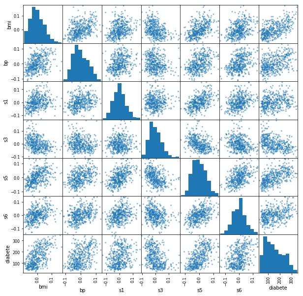

```python
diabete = load_diabetes()
data = pd.DataFrame(diabete.data,columns=diabete.feature_names)
data['diabete'] = pd.Series(diabete.target)

for ivar in ['sex','age','s2','s4']:
    if ivar in data:
        data.drop(ivar,axis=1,inplace=True)

ax = pd.plotting.scatter_matrix(data,figsize=(10,10))
```

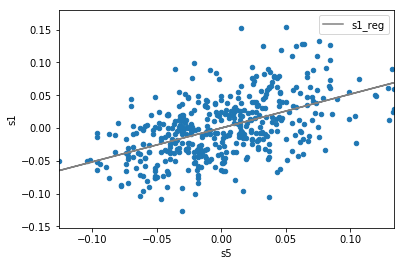

```python
ax = plt.figure().add_subplot(111)
ax = data.plot.scatter(ax=ax,x='s5',y='s1')
reg = LinearRegression().fit(data['s1'].values.reshape(-1, 1),data['s5'].values)
tmp = data.copy()
tmp['s1_reg'] = tmp['s5'] * reg.coef_[0] + reg.intercept_
tmp.plot.line(ax=ax,x='s5',y='s1_reg',color='grey')
```

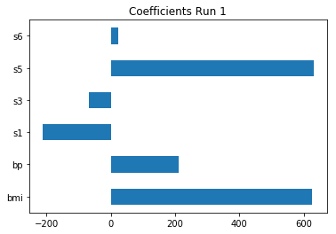

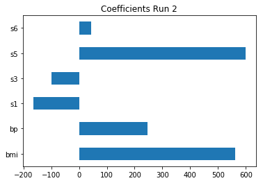

```python
target = 'diabete'
y = data[target].values
features = list(set(data.columns) - {target})
vec = DictVectorizer()
X = vec.fit_transform(data[features].to_dict(orient='records')).toarray()
X_train, X_test, y_train, y_test = train_test_split(X, y, test_size=0.2)
reg = LinearRegression().fit(X_train,y_train)
ax = pd.DataFrame(reg.coef_,vec.get_feature_names()).plot.barh(title='Coefficients Run 1',legend=False)

X_train, X_test, y_train, y_test = train_test_split(X, y, test_size=0.2)
reg = LinearRegression().fit(X_train,y_train)
ax = pd.DataFrame(reg.coef_,vec.get_feature_names()).plot.barh(title='Coefficients Run 2',legend=False)
```

The `coefficients` are the $\alpha$'s we learned before. What is important to notice in the figures above is that for 2 different runs of the fit, there are different results of coefficients. The 2 runs differ because we provide 2 different random subsets of the original data. However for the the regression model to be trustworthy there should not be 2 different results for the coefficients.

$10 = -1000 * s1 + 1505 * s5$

$10 = -2 * s1 + 8 * s5$

$10 = s1 + 3.5 * s5$

$10 = 5*s5$

**Which of the above approaches is the least complex?**

There is a general consensus that the approach that employs the smaller coefficients is the most trustworth because it is **less sensitive** to error in the values of explanatory variables; s1 and s5 in this example.

Being less sensitive to explanatory variable is important if you think that there could be error in their values. s1 and s5 are blood serum measurements after all. For sure they are not 100% accurate; for instance think about the instrument error.

Another widely accepted common sense justification for avoiding large coefficients or even accepting 0 value coefficients is the [Occam's razor](https://en.wikipedia.org/wiki/Occam%27s_razor): **"simpler solutions are more likely to be correct than complex ones."**

There is way to apply this principle to the regression technique. It's called **Regularization**. In the computation of the SSR that we looked at before, a penalty proportional to the absolute value of the coefficient or its square is introduced.

$$ SSR = \sum (y_{line,i} - y_i)^2 + L_1|w| $$$$ SSR = \sum (y_{line,i} - y_i)^2 + L_2||w||^2 $$

The $L_1$ approach is called **Lasso** regression and the $L_2$ approach is called **Ridge** regression.

Let us explore what occurs to the coefficient values when we apply 3 approaches:

- Linear Regression
- Lasso Regression
- Ridge Regression

with varying degrees of regularization.

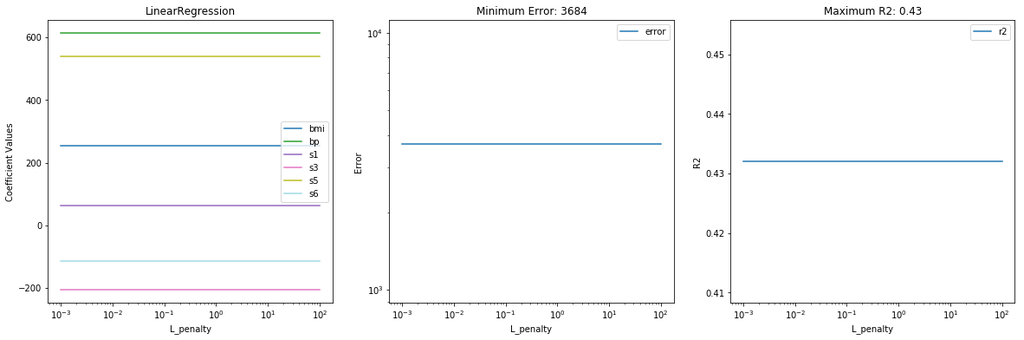

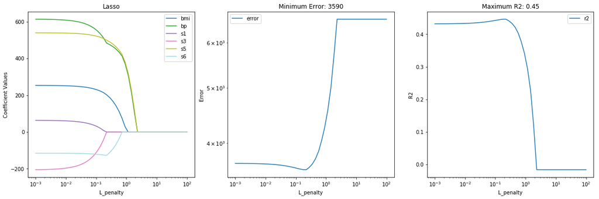

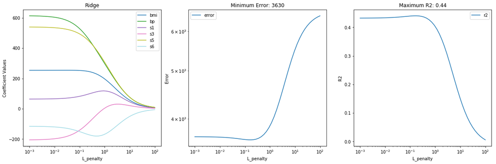

```python
def plotRegression(clf,X_train,y_train,X_test,y_test):

    alphas = np.logspace(-3, 2, 50)
    coefs = []
    errors = []

    for a in alphas:
        if type(clf) in [Ridge,Lasso]:
            clf.set_params(alpha=a)
            clf.fit(X_train, y_train)
        elif type(clf) in [LinearRegression]:
            clf.fit(X_train, y_train)

        icoef = dict(zip(features,clf.coef_))
        icoef['L_penalty'] = a
        icoef['error'] = mean_squared_error(clf.predict(X_test),y_test)
        icoef['r2'] = clf.score(X_test,y_test)

        coefs.append(icoef)

    plt.figure(figsize=(20, 6))

    plt.subplot(131)
    ax = plt.gca()
    cdata = pd.DataFrame(coefs).set_index('L_penalty',drop=True)
    ax.set_xscale('log')
    cdata.drop(['error','r2'],axis=1).plot.line(ax=ax,colormap=plt.get_cmap('tab20'))
    plt.ylabel('Coefficient Values')
    plt.axis('tight')
    plt.title(clf.__class__.__name__)

    plt.legend()

    plt.subplot(132)
    ax = plt.gca()
    cdata = pd.DataFrame(coefs).set_index('L_penalty',drop=True)
    ax.set_xscale('log')
    ax.set_yscale('log')
    cdata['error'].plot.line(ax=ax)
    plt.axis('tight')
    plt.ylabel('Error')
    plt.title('Minimum Error: '+str(int(cdata['error'].min())))
    plt.legend()

    plt.subplot(133)
    ax = plt.gca()
    cdata = pd.DataFrame(coefs).set_index('L_penalty',drop=True)
    ax.set_xscale('log')
    #ax.set_yscale('log')
    cdata['r2'].plot.line(ax=ax)
    plt.axis('tight')
    plt.ylabel('R2')
    plt.title('Maximum R2: '+str(np.round(cdata['r2'].max(),2)))
    plt.legend()

    plt.show()

X_train, X_test, y_train, y_test = train_test_split(X, y, test_size=0.1)
plotRegression(LinearRegression(),X_train,y_train,X_test,y_test)
plotRegression(Lasso(normalize=True),X_train,y_train,X_test,y_test)
plotRegression(Ridge(normalize=True),X_train,y_train,X_test,y_test)
```

By increasing the regularization strength, `L_penalty`, we see the coefficients values shrink, the error decrease, and the score, `R2`, increase. Up to a point where the opposite occurs. This shows that there is an optimal level of regularization that should be sought. It is also noteworthy that both Lasso and Ridge regressions have higher score than the standard regression approach for some values of `L_penalty`.

#### This plots are merely for demostration purpose and for explaining the concept of regularization. In fact, this dataset might not be suitable for regularization. More in depth analysis must be performed to confirm or rebut this results.

#### Also, we have not talked about another key technique, cross-validation, because it goes beyond the scope of this tutorial.